# When are top-down interactions strong?

## Modified code From Deyle et al. 2016

Deyle ER, May RM, Munch SB, Sugihara G. 2016 Tracking and forecasting ecosystem interactions in real time. Proc. R. Soc. B 283: 20152258. http://dx.doi.org/10.1098/rspb.2015.2258

This code will reproduce the core S-map calculations for a 4-species food web where a top Predator (P) feeds on two consumers (C1, C2), which in turn feed on a resource (R). This model structure was based of a model by Post et al. 2000.

Post, D. M., M. E. Conners, D. S. Goldberg. 2000. Prey preference by a top predator and the stability of linked food chains. Ecology 81(1), 8-14.

The core S-map calculations reduce to simply calculating weighted linear regression, so keep in mind that the majority of the code will simply be set-up.

First, we load the necessary packages. Note that the `echo = FALSE` parameter was added to the code chunk to prevent printing of the R code.

The mass-specific metabolic rates (xp and xc) scale the body size difference between the predator and consumer. Parameter values for consumer and predator can be specified to match empirical P:C body mass ratios (10-10^3; Peters 1983, Cohen et al. 1993).

The ingestion rates (yp and yc) constrain the metabolic type of the consumer and predaor (endotherm max value 1.6, vertebrate ectotherm max value 3.9, and invertebrate ectotherm max value 19.4; Yodzis & Innes 1992, McCann & Yodzies 1994).

The model uses a type II functional response for the consumers preying on the resours and the predator preying on the consumers.

Prey selection is incorporated into the model.

```r
params <- list(xp=0.08,  #Mass-specific metabolic rate of the predator
               yp=1.6, #Ingestion rate per unit metabolic rate of predator
               pp=0.5, #Prey preference of predator (0 <= pp <= 1).  At pp=1, P preys only on C1, at pp=0.5, P preys on C1 and C2 in proportion to their biomass (i.e. no preference), and at pp=0, P preys only on C2
               C1star=0.5, #Half-saturation density of consumer 1
               C2star=0.5, #Half-saturation density of consumer 2
               xc1=0.15, # Mass-specific metabolic rates of consumers , measured relative to the                             production-to-biomass ratio of the resource population
               xc2=0.15,
               yc1=3.9, #Ingestion rate per unit metabolic rate of consumers
               yc2=3.9,
               Rstar=0.3, #Half-saturation density of the resource
               k=1.2) #Carrying capacity

dR <- function(R,C1,C2,P) R*(1-R/params$k) -
  params$xc1*params$yc1*(C1*R)/(R+params$Rstar) -
  params$xc2*params$yc2*(C2*R)/(R+params$Rstar)

dC1 <- function(R,C1,C2,P) params$xc1*params$yc1*(C1*R)/(R+params$Rstar) -
    (params$pp*C1/(params$pp*C1+(1-params$pp)*C2))*params$xp*params$yp*(P*C1)/(C1+params$C1star) - params$xc1*C1

dC2 <- function(R,C1,C2,P) params$xc2*params$yc2*(C2*R)/(R+params$Rstar) -
    ((1-params$pp)*C2/(params$pp*C1+(1-params$pp)*C2))*params$xp*params$yp*(P*C2)/(C2+params$C2star) - params$xc2*C2

dP <- function(R,C1,C2,P) (params$pp*C1/(params$pp*C1+(1-params$pp)*C2))*params$xp*params$yp*(P*C1)/(C1+params$C1star) +
  ((1-params$pp)*C2/(params$pp*C1+(1-params$pp)*C2))*params$xp*params$yp*(P*C2)/(C2+params$C2star) -
    params$xp*P

dF <- function(R,C1,C2,P) c(dR(R,C1,C2,P), dC1(R,C1,C2,P), dC2(R,C1,C2,P), dP(R,C1,C2,P))
```

```r
tmax <- 10000; tau <- 5; dt <- 1/100; burn <- 200
d <- array(data = 0, dim = c(tmax/tau,4))
colnames(d) <- c( 'R' , 'C1' , 'C2' , 'P' )
```

We run the model with initial conditions (R, C1, C2, P) = (1, 0.5, 0.8, 0.7). Note that we start with a burn period to insure the dynamics relax to the attractor manifold.

```r
Xi <- c(1,.5,.8,.7)  #initial conditions for the 4 species (R, C1, C2, P)

#>>>RUN BURN<<<  start with a burn period to insure the dynamics relax to the attractor manifold
idex <- 0
while(idex< burn*(1/dt)){
    idex  <- idex+1;
Xi <- Xi + dt*do.call(dF,as.list(Xi)) }

#>>>RUN MODEL<<<
d[1,] <- Xi
idex <- 0; tdex <- 2
while(idex<tmax*(1/dt)){
idex <- idex+1;
Xi <- Xi + dt*do.call(dF,as.list(Xi))
    if( (idex*dt) %% tau == 0 && tdex < tmax/tau){
        d[tdex,] <- Xi
        tdex <- tdex+1
    }
}
```

Here, we are going to focus on the effects on consumer C1.

```r
targ_col <- 2
```

```r
Embedding <- c("R","C1","C2","P")
Edim <- length(Embedding)

d <- d[,Embedding]

coeff_names <- sapply(colnames(d),function(x) paste("d", colnames(d)[targ_col], "d", x, sep = ""))
```

```r
block <- cbind(d[2:dim(d)[1],targ_col],d[1:(dim(d)[1]-1),])
norm_consts <- apply(block, 2, function(x) sd(x))
block <- as.data.frame(apply(block, 2, function(x) (x-mean(x))/sd(x)))
```

We have a few final parameters to set for the S-map regression.

```r
lib <- 1:dim(block)[1]
pred <- 1:dim(block)[1]
theta <- 8
```

and we need to set up output.

```r
coeff <- array(0,dim=c(length(pred),Edim))
colnames(coeff) <- coeff_names
coeff <- as.data.frame(coeff)
```

Finally, to stay consistent with prior applications of S-maps, we will use SVD to solve the weighted linear regression. For ease, we put this into a single function that is similar to the basic lm() function in R. The lm() function could be used instead, but it computes the regression using QR instead of SVD.

```r
lm_svdsolve <- function(y, x, ws, subset = seq_along(y)){
  x <- x[subset,]
  y <- y[subset]
  ws <- ws[subset]

  # prepended column of 1s for constant term in linear model
  A <- cbind(1, x) * ws
  A_svd <- svd(A)

  # >>REMOVE SMALL SINGULAR VALUES<<
  s <- A_svd$d
  s_inv <- matrix(0, nrow = dim(x)[2]+1, ncol = dim(x)[2]+1)
  for(i in seq_along(s))
  {
    if(s[i] >= max(s) * 1e-5) s_inv[i,i] <- 1/s[i]
  }

  coeff <- A_svd$v %*% s_inv %*% t(A_svd$u) %*% (ws * y)
  coeff <- t(coeff)

  colnames(coeff) <- c("const",colnames(x))
  return(coeff)
}
```

Now, all the preceding code was just to set up the calculation. We now loop over each prediction point to actually calculate the S-map locally weighted regression for each prediction point. This calculation is quite simple. (1) We calculate the (normalized) Euclidian distance from the target point to the other points on the attractor. (2) These distances then become the weights for a weighted linear regression, which we solve using singular value decomposition (SVD).

```r
# >>CALCULATE COEFFICIENTS<<
for (ipred in 1:length(pred)){

  #target point is excluded from the fitting procedure
  libs = lib[-pred[ipred]]

  # >>CALCULATE WEIGHTS<<
  q <- matrix(as.numeric(block[pred[ipred],2:dim(block)[2]]),
              ncol=Edim, nrow=length(libs), byrow = T)
  distances <- sqrt(rowSums((block[libs,2:dim(block)[2]] - q)^2))
  dbar <- mean(distances)
  Ws <- exp(-theta*distances/dbar)

  # >>REGRESS<<
  svd_fit <- lm_svdsolve(block[libs,1],block[libs,2:dim(block)[2]],Ws)
  coeff[ipred,] <- svd_fit[-1]
}

coeff <- cbind(pred,coeff)
colnames(coeff)[1] <- "t"
```

We can plot a time series of these coeffcients over a span of time.

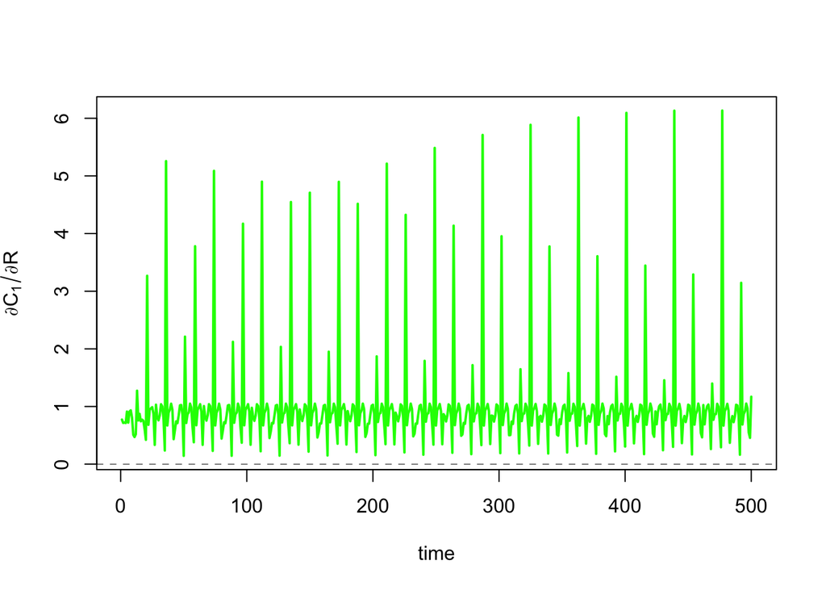

```r
par(mfrow = c(1,1))
trange <- 1:500

plot(coeff[trange,"t"],coeff[trange,"dC1dR"],type="l",col="green",xlab="time",
     ylab=expression(partialdiff*C[1] / partialdiff*R),
     ylim=range(coeff[trange,"dC1dR"]),xlim=range(trange),lwd=2)
abline(a=0 ,b=0 , lty="dashed", col="black", lwd=.5)
```

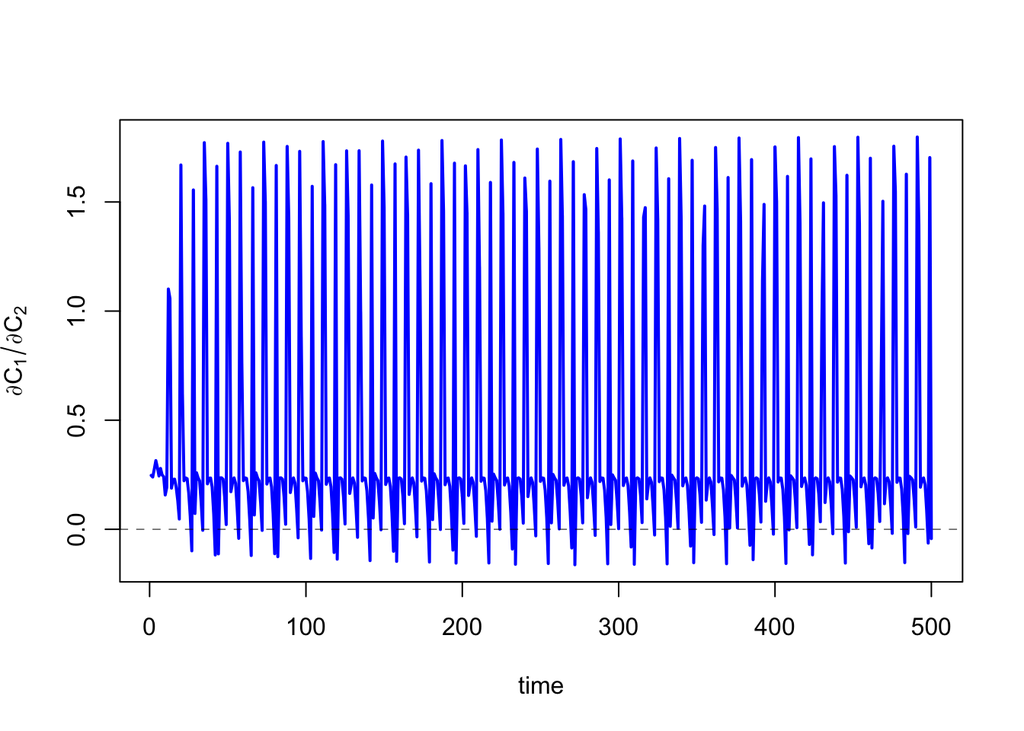

```r
plot(coeff[trange,"t"],coeff[trange,"dC1dC2"],type="l",col="blue",xlab="time",
     ylab=expression(partialdiff*C[1] / partialdiff*C[2]),
     ylim=range(coeff[trange,"dC1dC2"]),xlim=range(trange),lwd=2)
abline(a=0 ,b=0 , lty="dashed", col="black", lwd=.5)
```

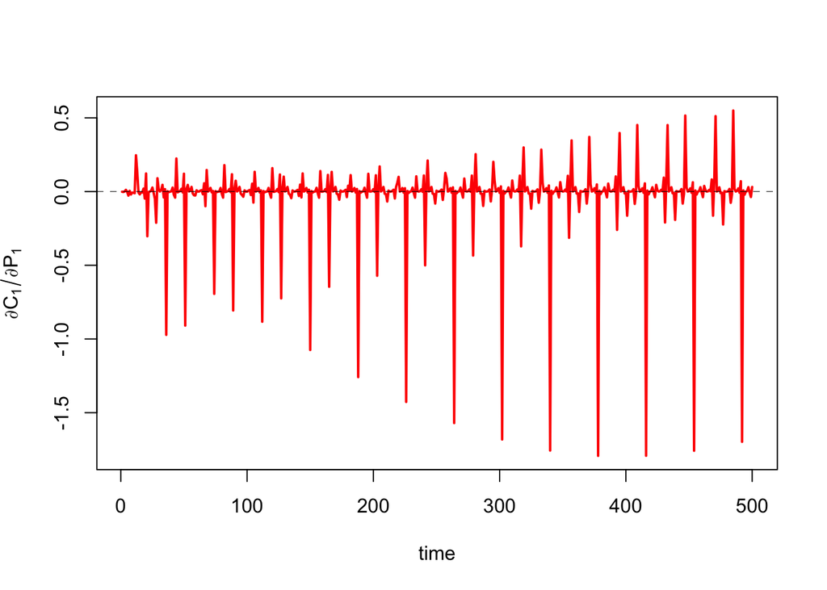

```r
plot(coeff[trange,"t"],coeff[trange,"dC1dP"],type="l",col="red",xlab="time",
     ylab=expression(partialdiff*C[1] / partialdiff*P[1]),
     ylim=range(coeff[trange,"dC1dP"]),xlim=range(trange),lwd=2)
abline(a=0 ,b=0 , lty="dashed", col="black", lwd=.5)
```

We can also plot the predation coeffcient to show how predation on C1 changes with resource-limitation for C1.

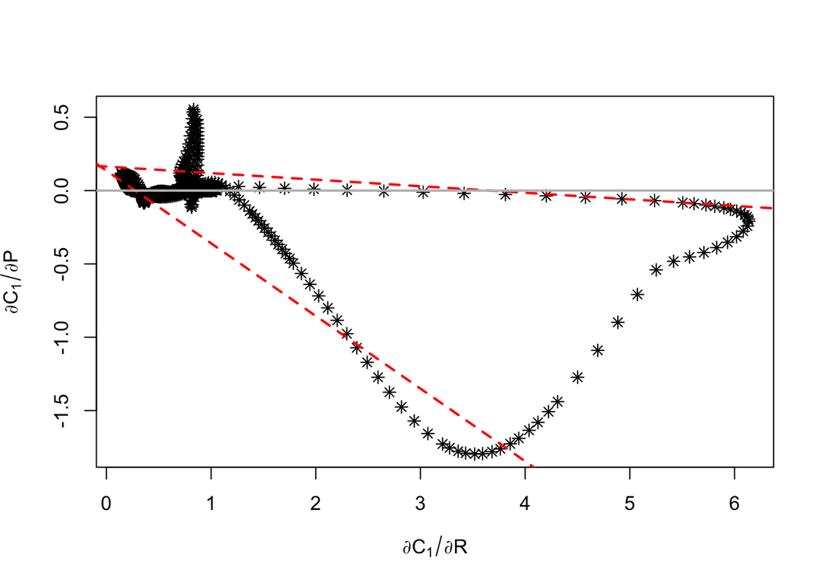

```r
qL <- rq(coeff$dC1dP ~ coeff$dC1dR,.05)
qU <- rq(coeff$dC1dP ~ coeff$dC1dR,.95)
plot(coeff[1001:1999, 'dC1dR' ],coeff[1001:1999, 'dC1dP' ],
     xlab=expression(partialdiff*C[1] / partialdiff*R),
     ylab=expression(partialdiff*C[1] / partialdiff*P),
     xlim=range(coeff[trange,"dC1dR"]),ylim=range(coeff[trange,"dC1dP"]),pch=8)
abline(a=qL$coefficients[1],b=qL$coefficients[2],lty=2,col='red',lwd=2)
abline(a=qU$coefficients[1],b=qU$coefficients[2],lty=2,col='red',lwd=2)
abline(a=0,b=0,lty=1,col='grey',lwd=2) #zero line
```

We can also plot the predation coefficient of P on C1 with respect to the competition coeffiction with species C2

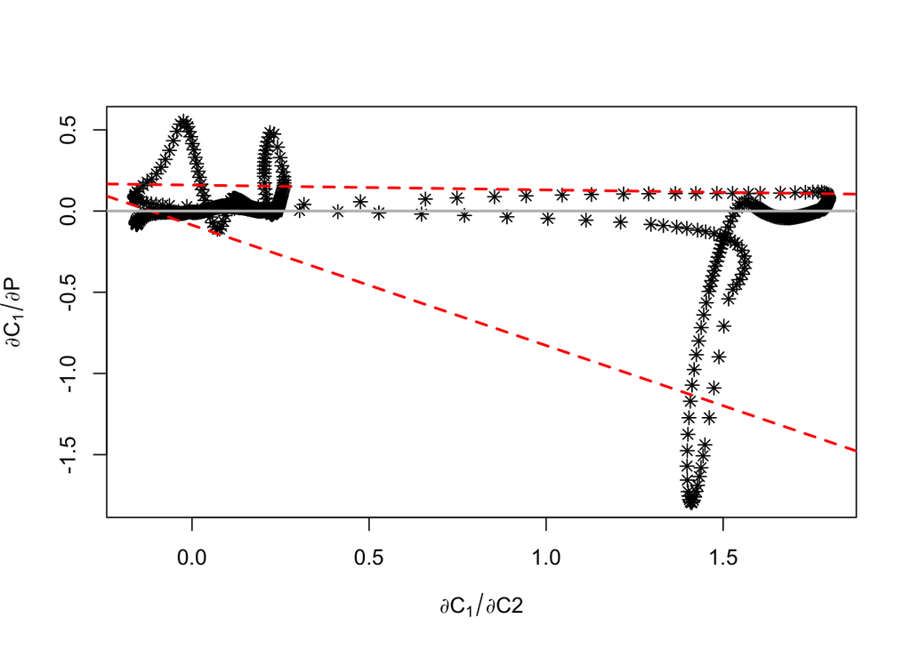

```r
qL <- rq(coeff$dC1dP ~ coeff$dC1dC2,.05)
qU <- rq(coeff$dC1dP ~ coeff$dC1dC2,.95)
plot(coeff[1001:1999, 'dC1dC2' ],coeff[1001:1999, 'dC1dP' ],
     xlab=expression(partialdiff*C[1] / partialdiff*C2),
     ylab=expression(partialdiff*C[1] / partialdiff*P),
     xlim=range(coeff[trange,"dC1dC2"]),ylim=range(coeff[trange,"dC1dP"]),pch=8)
abline(a=qL$coefficients[1],b=qL$coefficients[2],lty=2,col='red',lwd=2)
abline(a=qU$coefficients[1],b=qU$coefficients[2],lty=2,col='red',lwd=2)
abline(a=0,b=0,lty=1,col='grey',lwd=2) #zero line
```